# Seoul Bike Rentals Across the Seasons

Kang Shen: Jerry Gu, Roger Wang, Qingxin Geng, Tianao Chen & Wenbo Tang

2026-11-27

https://github.com/Hi-Light-Jerry/IDS-Project.git

## Research Question

Research question: How do mean hourly bike rentals differ between working days and non-working days in Seoul across the four seasons?

Two comparisons: the hour of peak rentals for each day type, and the difference in mean rentals at the same hour.

Practical relevance: identifying when bicycles are most needed over the course of a day.

## Data

Data source: Seoul Bike Sharing Demand, UCI Machine Learning Repository Unit of observation: one hour of recorded bicycle rentals across Seoul Study period: 1 December 2017 to 30 November 2018

- Original dataset: 8,760 hourly observations
- Operating hours included in the analysis: 8,465
- Non-operating hours excluded: 295
- Working days: Monday to Friday, excluding public holidays (5,712 operating hours)
- Non-working days: weekends and public holidays (2,753 operating hours)

## Methods

Using the 8,465 hours when the service was operating, we calculated mean hourly rentals for each combination of season, day type and hour of day. For each season, we plotted separate curves for working and non-working days and identified the hour with the highest mean on each curve. We then compared the two groups at each hour by subtracting mean rentals on non-working days from mean rentals on working days. The largest positive gap occurred at 08:00 in all four seasons, so we examined the 353 observations recorded at that hour. We fitted two linear models. The first assumed a common working-day gap across seasons, while the second allowed the gap to vary by season. We compared the models using adjusted R² and examined variation within each group using residual boxplots and residual standard deviations from the second model.

## Findings

### Hourly rental patterns by season

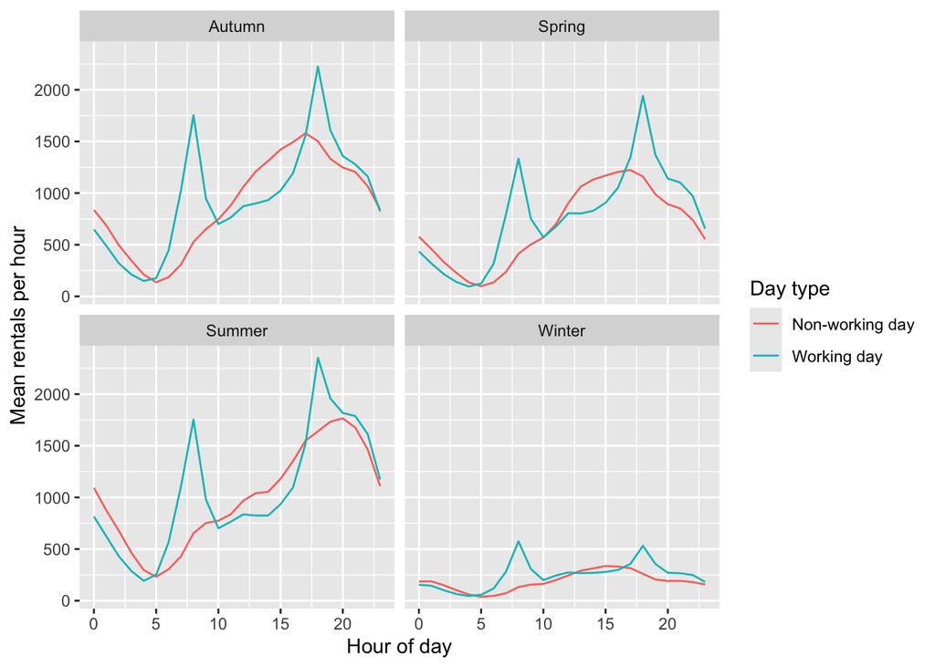

### Peak times and differences in hourly rentals

| Season | Working-day peak | Non-working-day peak | Gap at 08:00 | Gap at 15:00 |
| --- | --- | --- | --- | --- |
| Spring | 18:00 | 17:00 | +920 | −263 |
| Summer | 18:00 | 20:00 | +1,100 | −246 |
| Autumn | 18:00 | 17:00 | +1,227 | −398 |
| Winter | 08:00 | 15:00 | +442 | −57 |

*Gap = mean rentals on working days minus mean rentals on non-working days, in bikes per hour. Values are rounded to the nearest whole bike.* We compared working-day and non-working-day rentals at each of the 24 hours. We chose 08:00 for a closer look because the largest positive gap occurred at 08:00 in each of the four seasons.

### Does the working-day gap at 08:00 vary by season?

```
## [1] 0.5973375
```

```
## [1] 0.6296473
```

### How much do rentals vary within each group at 08:00?

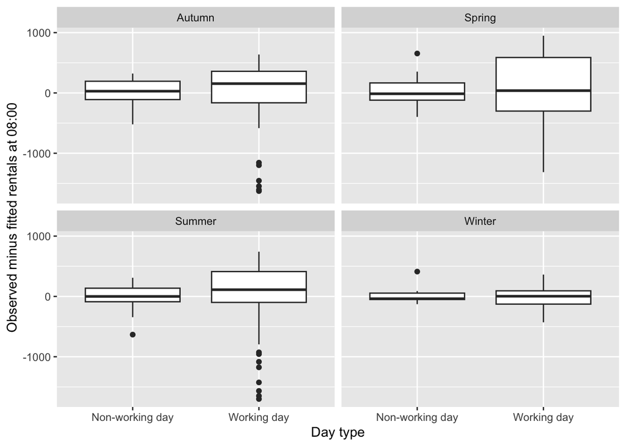

```
## # A tibble: 8 × 3
## # Groups:   season [4]
##   season day_type        residual_sd
##   <chr>  <chr>                 <dbl>
## 1 Autumn Non-working day       242.
## 2 Autumn Working day           582.
## 3 Spring Non-working day       247.
## 4 Spring Working day           656.
## 5 Summer Non-working day       199.
## 6 Summer Working day           593.
## 7 Winter Non-working day        95.2
## 8 Winter Working day           162.
```

At 08:00, the residual standard deviation was larger on working days in all four seasons. In spring, it was about 656 rentals per hour on working days and 247 on non-working days.

## Discussion and limitations

On working days, mean hourly rentals peaked at 18:00 in spring, summer and autumn, and at 08:00 in winter. On non-working days, the peak occurred at 15:00 in winter, 17:00 in spring and autumn, and 20:00 in summer. Across all four seasons, 08:00 was the hour when working-day rentals exceeded non-working-day rentals by the largest margin. The size of this morning gap varied considerably, from about 442 rentals per hour in winter to 1,227 in autumn.

The data cover one year in Seoul, so each season was observed only once. A second year of data would help establish whether the same peak times and morning gaps recur. We selected 08:00 after comparing all 24 hours. For the 353 mornings observed at that hour, allowing the working-day gap to vary by season increased the adjusted R² from 0.5973 to 0.6296. This indicates a better fit to the observed mornings. Predictive performance on future mornings remains untested.

## References

Easwaramoorthy, S. (2020). Seoul Bike Sharing Demand [Dataset]. UCI Machine Learning Repository. https://doi.org/10.24432/C5F62R.